# ISA616 Analytic Workflow

KUNZHAN LI

October 1,2020

## 0.1 Manage Packages

```r
if(require(pacman)==FALSE) install.packages("pacman")
pacman::p_load(readxl,fpp2,ggplot2,scales,dplyr,tidyr,DataExplorer,forecast)
```

# 1 Introduction

Capital BikeShare is a bikeshare system offering new generation of bike rentals service to customers. In this data analysis project, I attempt to find out how factors affect the number of shared bike rental and use model to predict the number of shared bike rental for a specific day.By doing this analysis, Capital Bikeshare could prepare enough bikes for the customers, and therefore improves the customer services.

- Business Value Proposition:

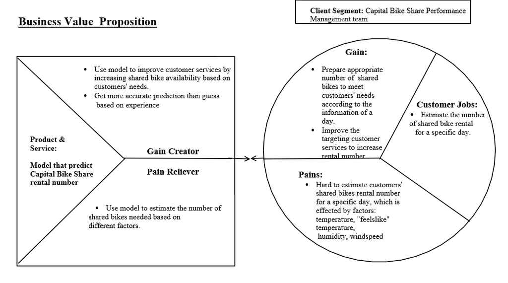

# 2 Data Description

The data source is from capitalbikes.com. It originally has 10886 observations and 12 variables.Variables are: “datetime”,“season”,“holiday”,“workingday”,“weather”,“temp”,“atemp”,“humidity” “windspeed”,“casual”,“registered”,and “count”. * “datetime” is the date variable. * “season” is a categorical variable, in which “1” represents for spring, “2” represents for summer, “3” represents for fall,and “4” represents for winter. * “holiday” is a binary variable that tells whether the day is considered a holiday. * “workingday” is a binary that tells whether the day is neither a weekend nor holiday. * “weather” is a categorical variable. “1”is Clear, Few clouds, Partly cloudy, Partly cloudy. “2” is Mist + Cloudy, Mist + Broken clouds, Mist + Few clouds, Mist.“3”is Light Snow, Light Rain + Thunderstorm + Scattered clouds, Light Rain + Scattered clouds. “4”is Heavy Rain + Ice Pallets + Thunderstorm + Mist, Snow + Fog. * “temp”,temperature in Celsius,is a numerical variable  
* “atemp” is the numerical variable that stands for “feels like” temperature in Celsius. * “humidity” is the numerical variable that stands for relative humidity * “windspeed”,wind speed, is a numerical variable. * “casual” is the numerical variable that stands for the number of non-registered user rentals initiated. * “registered” is the numerical variable that stands for the number of registered user rentals initiated. * “count” is the numerical variable that stands for the number of total rentals.

```r
setwd("C:\\Users\\yolan\\Downloads\\ISA616HW\\week 6\\Analytics Workflow\\BikeShare")
data <- read_xlsx("Bike_sharing Project Data.xlsx")
```

## 2.1 data summary

```r
head(data)
```

| datetime | season | holiday | workingday | weather | temp | atemp | humidity | windspeed | casual | registered | count |
| --- | --- | --- | --- | --- | --- | --- | --- | --- | --- | --- | --- |
| 2011-01-01 00:00:00 | 1 | 0 | 0 | 1 | 9.84 | 14.395 | 81 | 0.0000 | 3 | 13 | 16 |
| 2011-01-01 01:00:00 | 1 | 0 | 0 | 1 | 9.02 | 13.635 | 80 | 0.0000 | 8 | 32 | 40 |
| 2011-01-01 02:00:00 | 1 | 0 | 0 | 1 | 9.02 | 13.635 | 80 | 0.0000 | 5 | 27 | 32 |
| 2011-01-01 03:00:00 | 1 | 0 | 0 | 1 | 9.84 | 14.395 | 75 | 0.0000 | 3 | 10 | 13 |
| 2011-01-01 04:00:00 | 1 | 0 | 0 | 1 | 9.84 | 14.395 | 75 | 0.0000 | 0 | 1 | 1 |
| 2011-01-01 05:00:00 | 1 | 0 | 0 | 2 | 9.84 | 12.880 | 75 | 6.0032 | 0 | 1 | 1 |

```r
tail(data)
```

| datetime | season | holiday | workingday | weather | temp | atemp | humidity | windspeed | casual | registered | count |
| --- | --- | --- | --- | --- | --- | --- | --- | --- | --- | --- | --- |
| 2012-12-19 18:00:00 | 4 | 0 | 1 | 1 | 15.58 | 19.695 | 50 | 23.9994 | 23 | 546 | 569 |
| 2012-12-19 19:00:00 | 4 | 0 | 1 | 1 | 15.58 | 19.695 | 50 | 26.0027 | 7 | 329 | 336 |
| 2012-12-19 20:00:00 | 4 | 0 | 1 | 1 | 14.76 | 17.425 | 57 | 15.0013 | 10 | 231 | 241 |
| 2012-12-19 21:00:00 | 4 | 0 | 1 | 1 | 13.94 | 15.910 | 61 | 15.0013 | 4 | 164 | 168 |
| 2012-12-19 22:00:00 | 4 | 0 | 1 | 1 | 13.94 | 17.425 | 61 | 6.0032 | 12 | 117 | 129 |
| 2012-12-19 23:00:00 | 4 | 0 | 1 | 1 | 13.12 | 16.665 | 66 | 8.9981 | 4 | 84 | 88 |

```r
str(data)
```

```
## tibble [10,886 x 12] (S3: tbl_df/tbl/data.frame)
##  $ datetime  : POSIXct[1:10886], format: "2011-01-01 00:00:00" "2011-01-01 01:00:00" ...
##  $ season    : num [1:10886] 1 1 1 1 1 1 1 1 1 1 ...
##  $ holiday   : num [1:10886] 0 0 0 0 0 0 0 0 0 0 ...
##  $ workingday: num [1:10886] 0 0 0 0 0 0 0 0 0 0 ...
##  $ weather   : num [1:10886] 1 1 1 1 1 2 1 1 1 1 ...
##  $ temp      : num [1:10886] 9.84 9.02 9.02 9.84 9.84 ...
##  $ atemp     : num [1:10886] 14.4 13.6 13.6 14.4 14.4 ...
##  $ humidity  : num [1:10886] 81 80 80 75 75 75 80 86 75 76 ...
##  $ windspeed : num [1:10886] 0 0 0 0 0 ...
##  $ casual    : num [1:10886] 3 8 5 3 0 0 2 1 1 8 ...
##  $ registered: num [1:10886] 13 32 27 10 1 1 0 2 7 6 ...
##  $ count     : num [1:10886] 16 40 32 13 1 1 2 3 8 14 ...
```

```r
summary(data)
```

```
##     datetime                       season         holiday
##  Min.   :2011-01-01 00:00:00   Min.   :1.000   Min.   :0.00000
##  1st Qu.:2011-07-02 07:15:00   1st Qu.:2.000   1st Qu.:0.00000
##  Median :2012-01-01 20:30:00   Median :3.000   Median :0.00000
##  Mean   :2011-12-27 05:56:22   Mean   :2.507   Mean   :0.02857
##  3rd Qu.:2012-07-01 12:45:00   3rd Qu.:4.000   3rd Qu.:0.00000
##  Max.   :2012-12-19 23:00:00   Max.   :4.000   Max.   :1.00000
##    workingday        weather           temp           atemp
##  Min.   :0.0000   Min.   :1.000   Min.   : 0.82   Min.   : 0.76
##  1st Qu.:0.0000   1st Qu.:1.000   1st Qu.:13.94   1st Qu.:16.66
##  Median :1.0000   Median :1.000   Median :20.50   Median :24.24
##  Mean   :0.6809   Mean   :1.418   Mean   :20.23   Mean   :23.66
##  3rd Qu.:1.0000   3rd Qu.:2.000   3rd Qu.:26.24   3rd Qu.:31.06
##  Max.   :1.0000   Max.   :4.000   Max.   :41.00   Max.   :45.45
##     humidity        windspeed          casual         registered
##  Min.   :  0.00   Min.   : 0.000   Min.   :  0.00   Min.   :  0.0
##  1st Qu.: 47.00   1st Qu.: 7.002   1st Qu.:  4.00   1st Qu.: 36.0
##  Median : 62.00   Median :12.998   Median : 17.00   Median :118.0
##  Mean   : 61.89   Mean   :12.799   Mean   : 36.02   Mean   :155.6
##  3rd Qu.: 77.00   3rd Qu.:16.998   3rd Qu.: 49.00   3rd Qu.:222.0
##  Max.   :100.00   Max.   :56.997   Max.   :367.00   Max.   :886.0
##      count
##  Min.   :  1.0
##  1st Qu.: 42.0
##  Median :145.0
##  Mean   :191.6
##  3rd Qu.:284.0
##  Max.   :977.0
```

```r
dim(data)
```

```
## [1] 10886    12
```

```r
names(data)
```

```
##  [1] "datetime"   "season"     "holiday"    "workingday" "weather"
##  [6] "temp"       "atemp"      "humidity"   "windspeed"  "casual"
## [11] "registered" "count"
```

## 2.2 checking missing data: There is no missing data.

```r
sum(is.na(data))
```

```
## [1] 0
```

```r
introduce(data)
```

| rows | columns | discrete_columns | continuous_columns | all_missing_columns | total_missing_values | complete_rows | total_observations | memory_usage |
| --- | --- | --- | --- | --- | --- | --- | --- | --- |
| 10886 | 12 | 1 | 11 | 0 | 0 | 10886 | 130632 | 1048920 |

# 3 Data Preprocessing

## 3.1 variable type corretion

The variables:“season”,“holiday”,“workingday”,and “weather” are not in correct variable type, so first I need to change these categorical variables to factor.

```r
data$season <- as.factor(data$season)
data$holiday <- as.factor(data$holiday)
data$workingday <- as.factor(data$workingday)
data$weather <- as.factor(data$weather)
```

```r
data$temp <- as.numeric(data$temp)
data$humidity <- as.numeric(data$humidity)
data$casual <- as.numeric(data$casual)
data$registered <- as.numeric(data$registered)
data$count <- as.numeric(data$count)
```

## 3.2 create new variables

I create two new categorical variables:“Month”, “Time”, and label them as factors so that I can analyze the their relationship with the number of shared bike rental respectively.Then I delete “datetime” since it would not be helpful for generating model and make predictions.

```r
data$Month <- sapply(strsplit(as.character(data$datetime), "-"), "[", 2)
data$Time <- sapply(strsplit(as.character(data$datetime), " "), "[", 2)

data$Month <- as.factor(data$Month)
data$Time <- as.factor(data$Time)
```

```r
data <- select(data,-datetime)
```

Now, check the level of the variables.

```r
sapply(data, levels)
```

[output not shown]

## 3.3 check abnormal and outlier

Next, I would like to look at the summary statistics and plots to check if there is any abnormal data or outlier. Remove them if they exist.

```r
summary(data)
```

```
##  season   holiday   workingday weather       temp           atemp
##  1:2686   0:10575   0:3474     1:7192   Min.   : 0.82   Min.   : 0.76
##  2:2733   1:  311   1:7412     2:2834   1st Qu.:13.94   1st Qu.:16.66
##  3:2733                        3: 859   Median :20.50   Median :24.24
##  4:2734                        4:   1   Mean   :20.23   Mean   :23.66
##                                         3rd Qu.:26.24   3rd Qu.:31.06
##                                         Max.   :41.00   Max.   :45.45
##
##     humidity        windspeed          casual         registered
##  Min.   :  0.00   Min.   : 0.000   Min.   :  0.00   Min.   :  0.0
##  1st Qu.: 47.00   1st Qu.: 7.002   1st Qu.:  4.00   1st Qu.: 36.0
##  Median : 62.00   Median :12.998   Median : 17.00   Median :118.0
##  Mean   : 61.89   Mean   :12.799   Mean   : 36.02   Mean   :155.6
##  3rd Qu.: 77.00   3rd Qu.:16.998   3rd Qu.: 49.00   3rd Qu.:222.0
##  Max.   :100.00   Max.   :56.997   Max.   :367.00   Max.   :886.0
##
##      count           Month            Time
##  Min.   :  1.0   05     : 912   12:00:00: 456
##  1st Qu.: 42.0   06     : 912   13:00:00: 456
##  Median :145.0   07     : 912   14:00:00: 456
##  Mean   :191.6   08     : 912   15:00:00: 456
##  3rd Qu.:284.0   12     : 912   16:00:00: 456
##  Max.   :977.0   10     : 911   17:00:00: 456
##                  (Other):5415   (Other) :8150
```

- There is only one day has Weather4 condition with 164 total shared bike rentals. I would like to merge it into Weather3 to reduce the number of dummy variables so that I have fewer predictors and better model.

```r
data$weather <- recode_factor(data$weather,"4"="3")
table(data$weather)
```

```
##
##    3    1    2
##  860 7192 2834
```

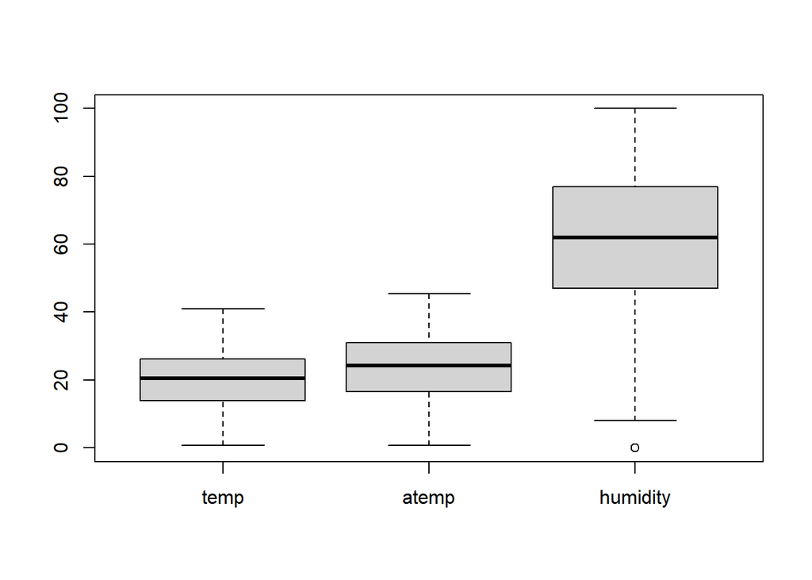

```r
boxplot(data[,5:7], col="lightgrey")
```

- There is one outlier with “humidity”= 0.Remove it.

```r
data = data[-which(data$humidity==0),]
```

## 3.4 calculate user proportions

I would like to see the proportions of the number of shared bike non-registered and registered user rental over the total number of shared bike rental.

```r
sum(data$casual)
```

```
## [1] 392089
```

```r
sum(data$count)
```

```
## [1] 2084853
```

```r
392135/2085476
```

```
## [1] 0.1880314
```

```r
sum(data$registered)
```

```
## [1] 1692764
```

```r
 1693341/2085476
```

```
## [1] 0.8119686
```

Around 18.80% of the shared bike rentals are initiated by non-registered users, and 81.20% of the shared bike rentals are initiated by registered users.

# 4 Data Analysis

## 4.1 Data Visualization

### 4.1.1 plots

First,I want to look at the plots for the variables.

Below see a summary of the qualitative variables.

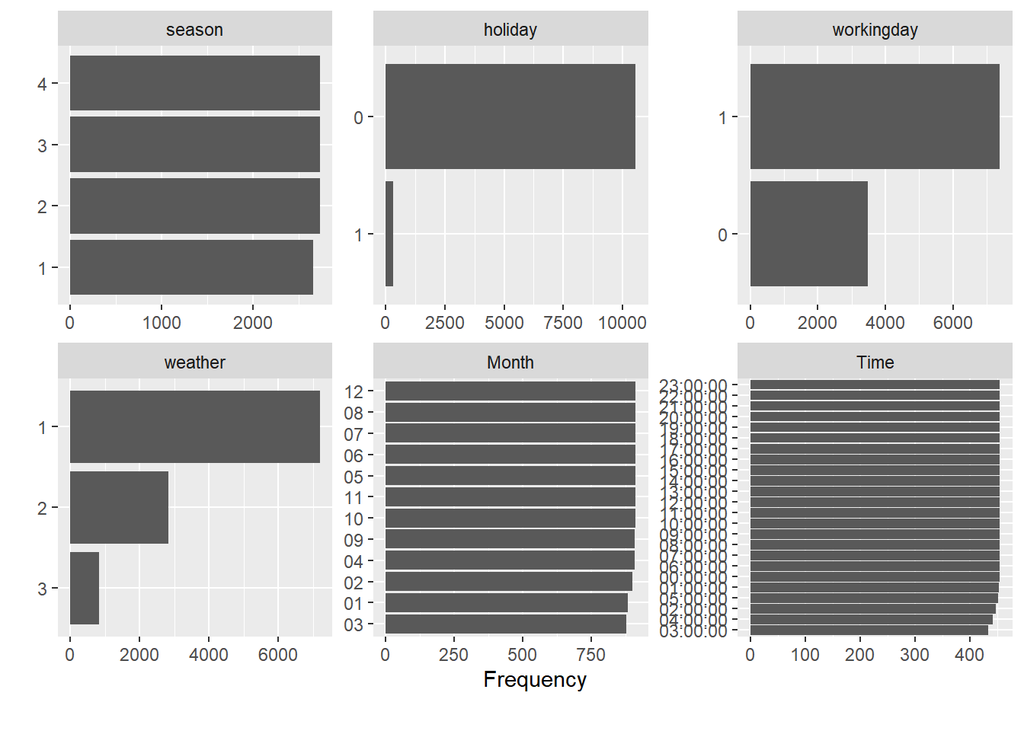

```r
plot_bar(data)
```

```r
prop.table(table(data$weather))
```

```
##
##          3          1          2
## 0.07731959 0.66200295 0.26067747
```

Below see a summary of the quantitative variables. “casual”, “count”, and“registered” are right skewed.

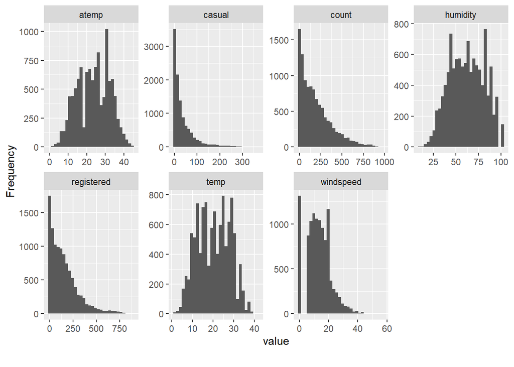

```r
plot_histogram(data)
```

### 4.1.2 quantitative variables correlation

I would like to see which quantitative variables are highly correlated, especially how other variables are correlated with “casual”,“registered”,and “count”.

I can conclude that the number of shared bike rentals is moderately positively affected by temperature,“feels like” temperature, and negatively affected by humidity of a specific day. Also, temperature, “feels like” temperature, and humidity have larger effect on the number of non-registered user rentals initiated than the number of registered user rentals initiated.

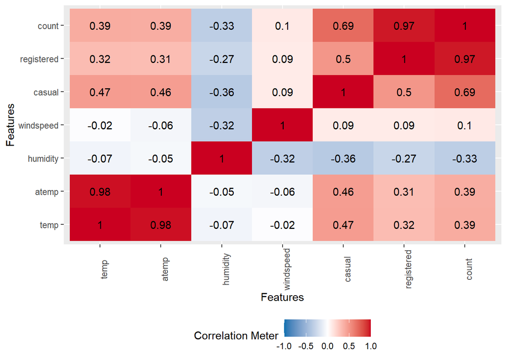

```r
plot_correlation(data,type = "c")
```

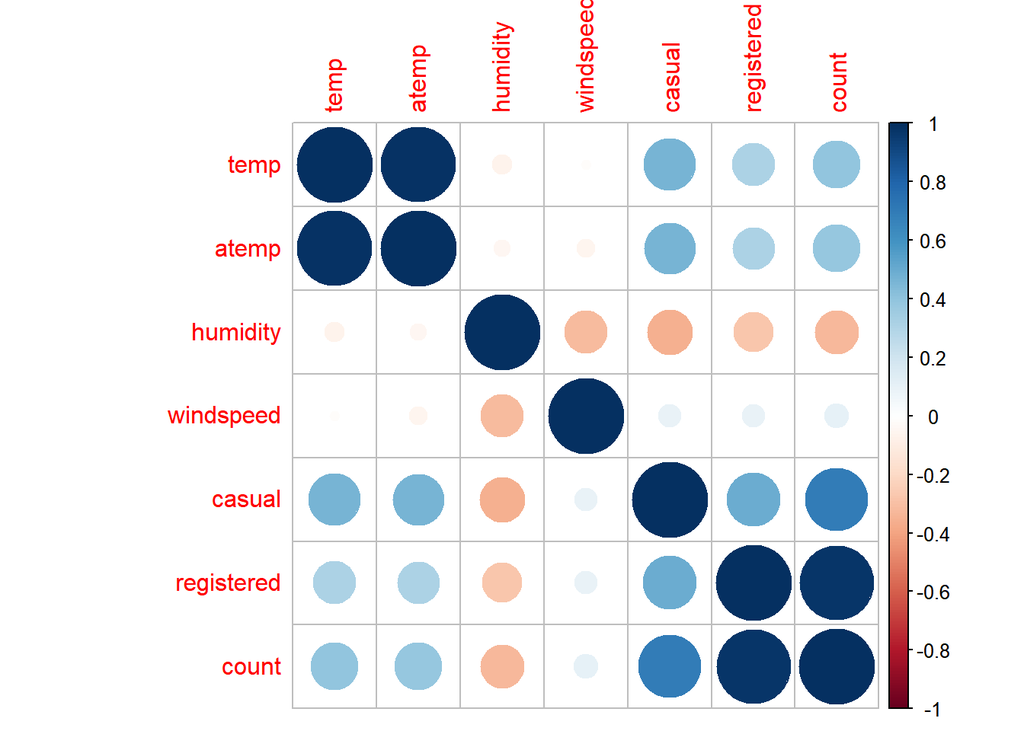

```r
nums <- unlist(lapply(data, is.numeric))
data.num <- data[,nums]
M<-cor(data.num, use = "complete.obs")
library("corrplot")
corrplot(M, method='circle')
```

```r
data <- select(data,-atemp)
data <- select(data,-windspeed)
```

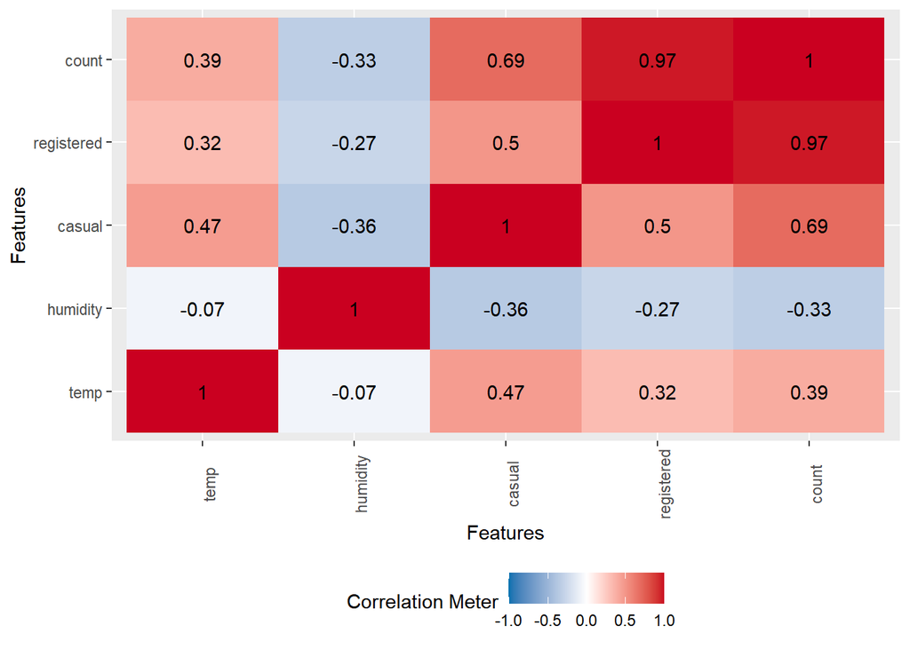

```r
plot_correlation(data,type = "c")
```

### qualitative variables relationship I would like to see the relationship between “casual”,“registered”,“count” and qualitative variables,“season”,“holiday”,“workingday”,“weather”,“Month”,“Time”.“Holiday” and “workingday” are binary variables.

#### 4.1.2.1 Let’s look at the relationship between “season” and “casual”,“registered”,“count”, respectively.

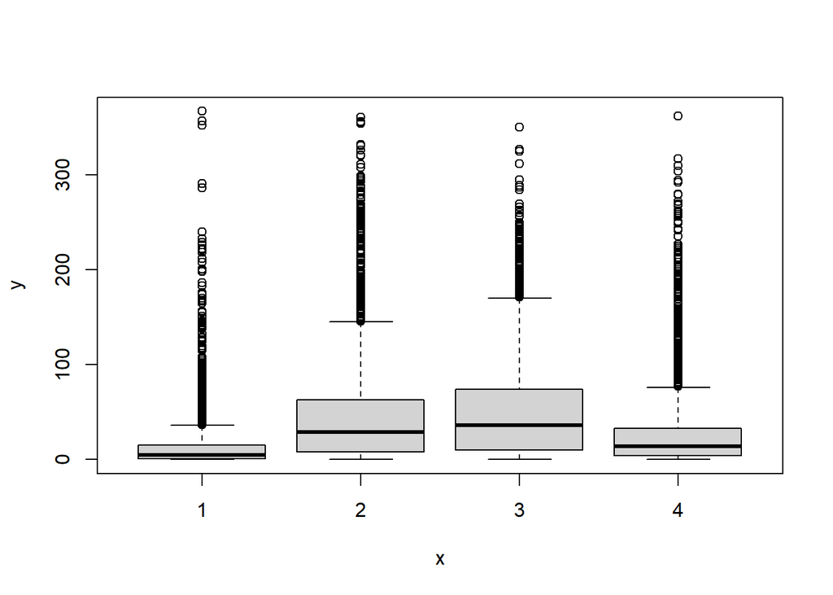

```r
plot(data$season,data$casual)
```

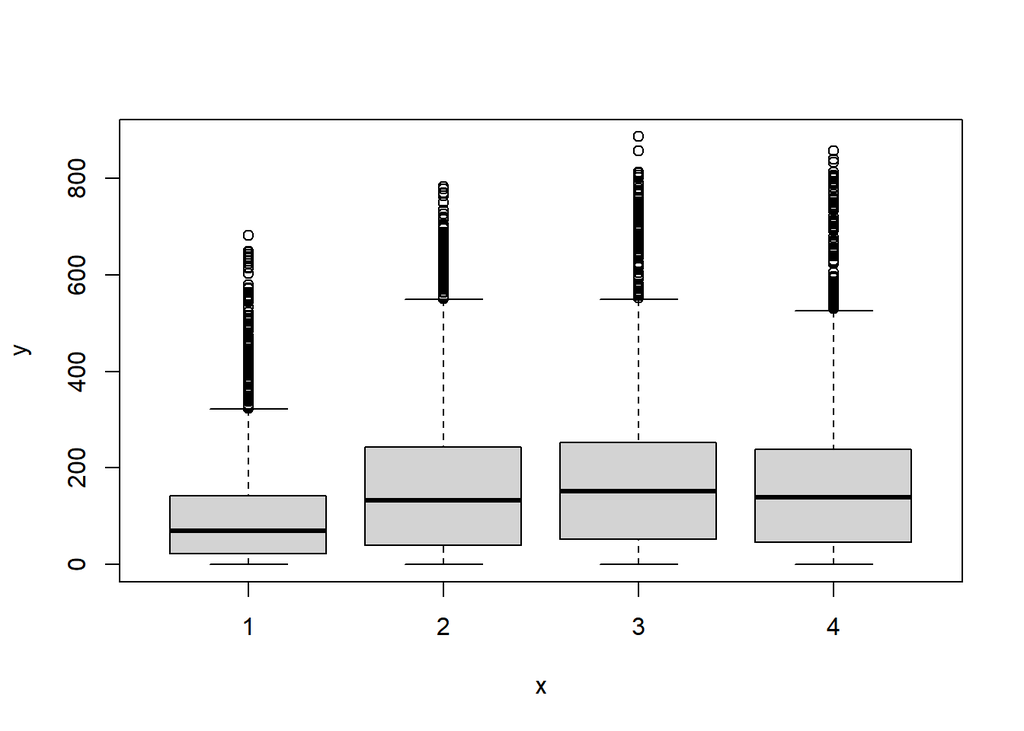

```r
plot(data$season,data$registered)
```

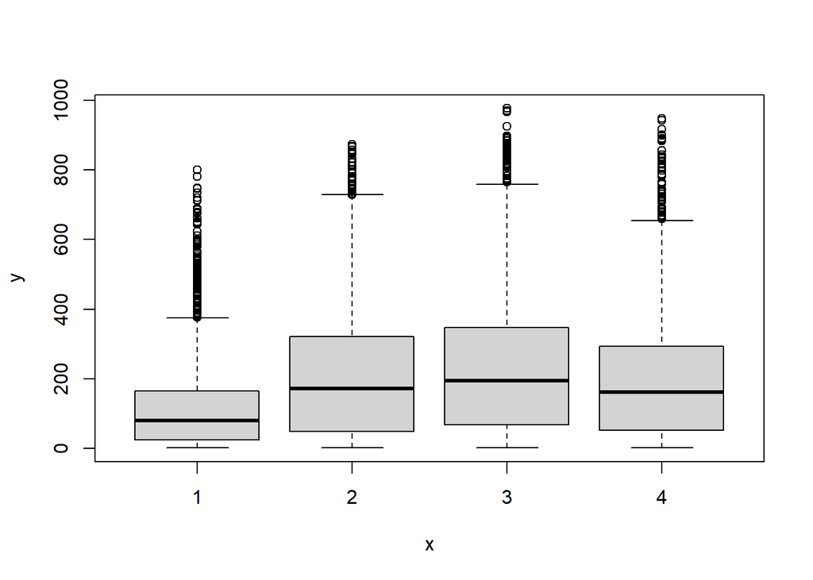

```r
plot(data$season,data$count)
```

- we can observe that Summer and Fall have lager number of shared bike rental overall.However, there are less shared bike used in winter for non-register customers than registered customers.

#### 4.1.2.2 Let’s look at “holiday” and “casual”,“registered”,“count”, respectively.

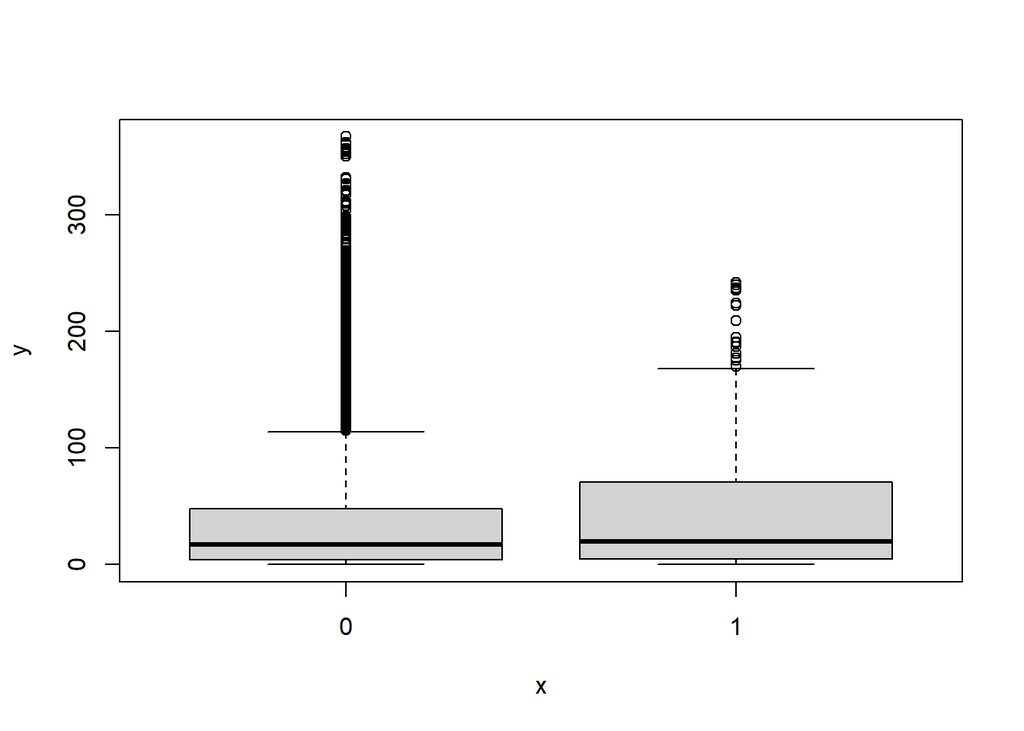

```r
plot(data$holiday,data$casual)
```

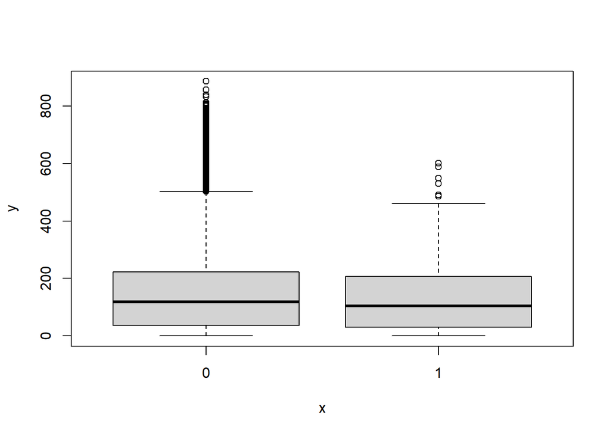

```r
plot(data$holiday,data$registered)
```

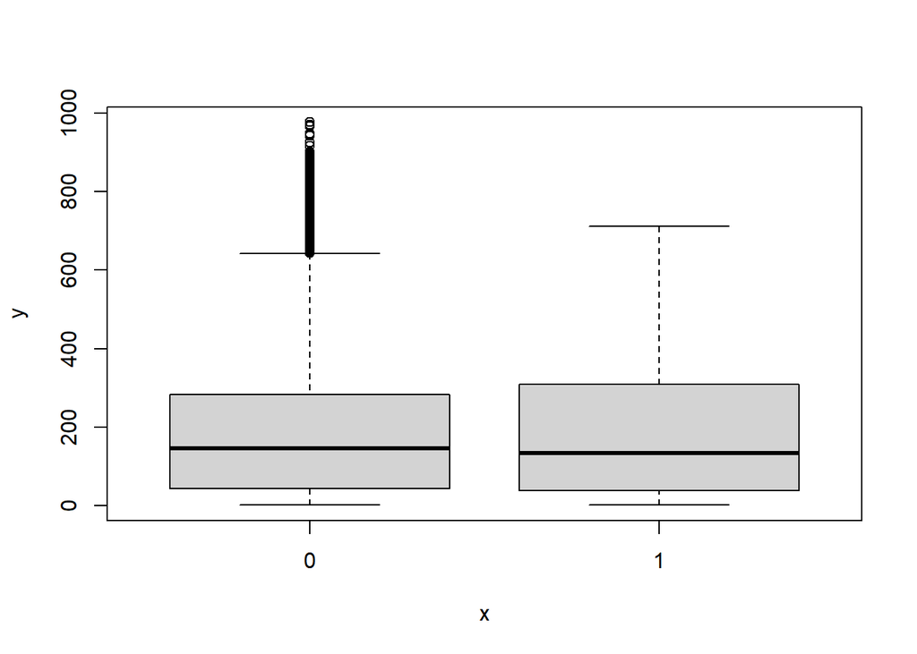

```r
plot(data$holiday,data$count)
```

* we can see that more registered use shared rental bikes when it is not a holiday, while more non-registered customers use shared rental bikes during holiday.

#### 4.1.2.3 Let’s look at the relationship between “workingday” and “casual”,“registered”,“count”, respectively.

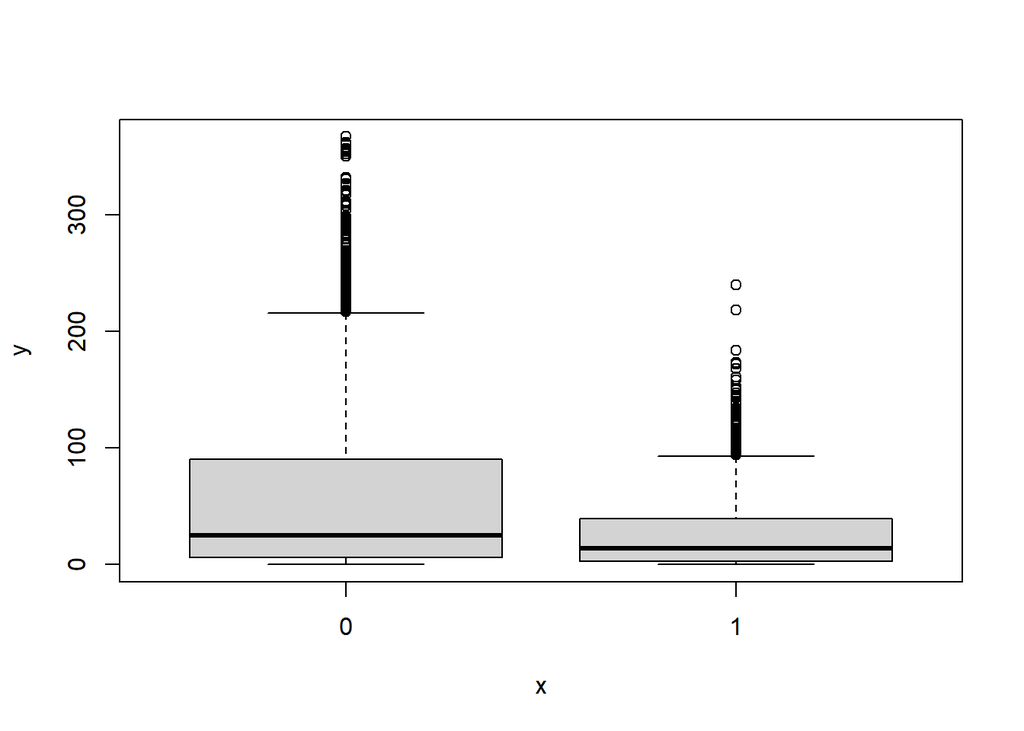

```r
plot(data$workingday,data$casual)
```

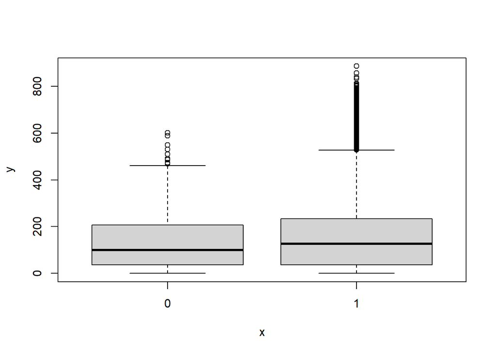

```r
plot(data$workingday,data$registered)
```

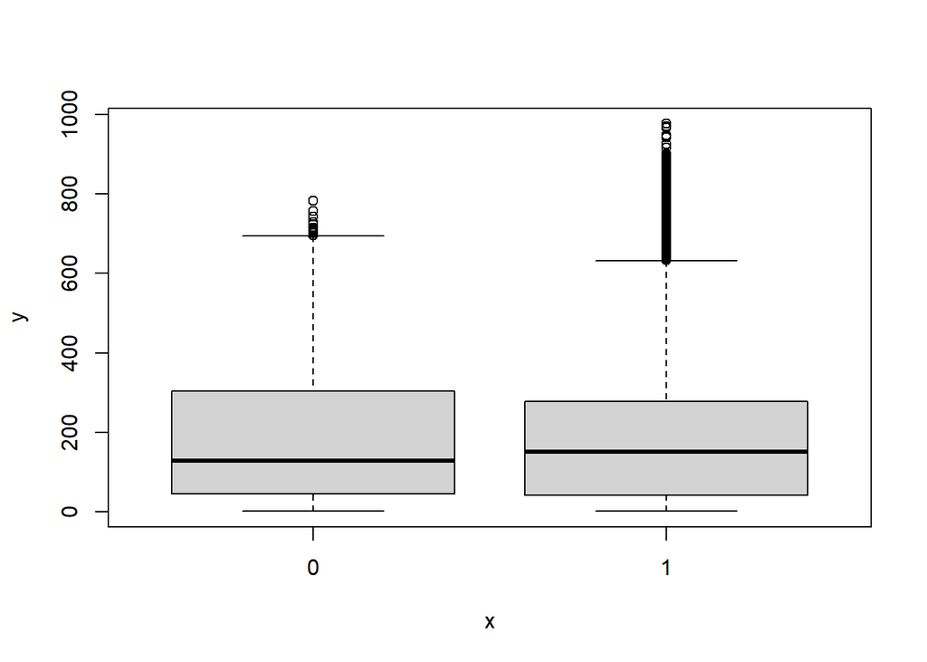

```r
plot(data$workingday,data$count)
```

* we can observe that most non-registered customers use shared bike on non weekday, while most registered customers use shared bike on weekdays.

#### 4.1.2.4 Let’s look at “weather” and “casual”,“registered”,“count”, respectively.

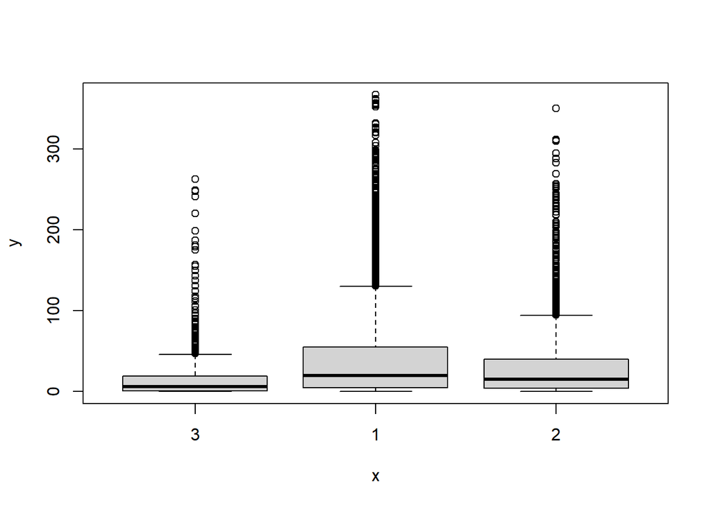

```r
plot(data$weather,data$casual)
```

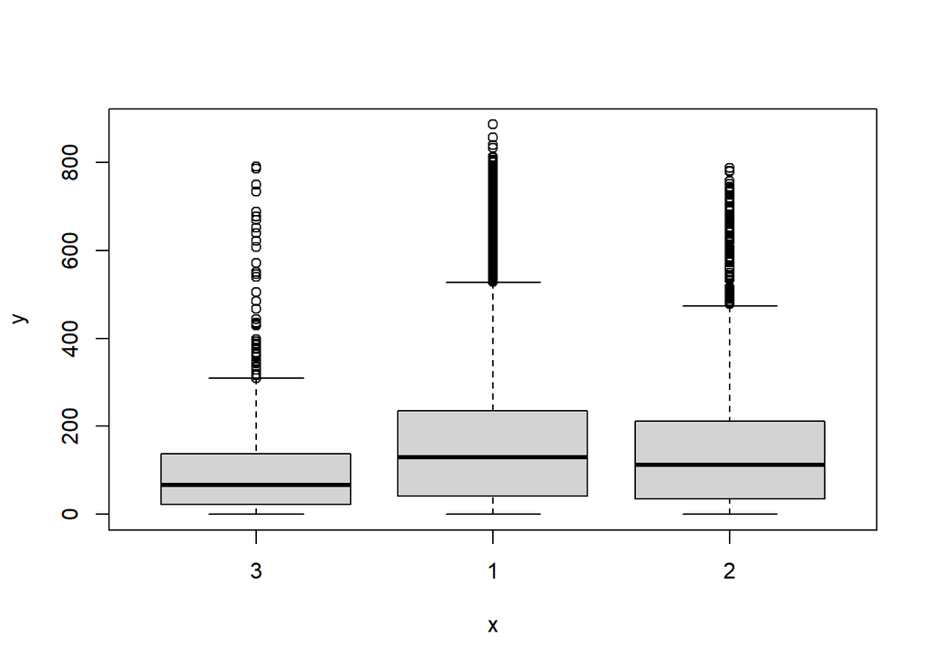

```r
plot(data$weather,data$registered)
```

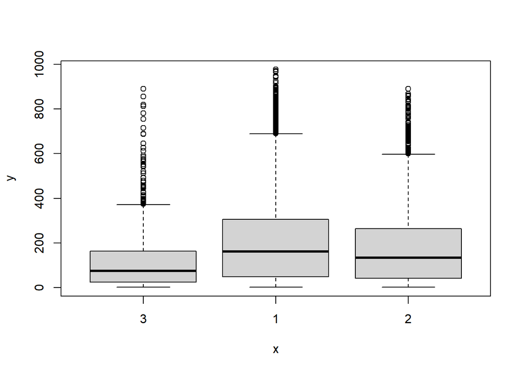

```r
plot(data$weather,data$count)
```

* The majority of the customers use shared bikes when weather is in condition “1”, which is Clear, Few clouds, Partly cloudy, Partly cloudy.When weather is in worse condition(“2”,“3”), fewer customers use shared bikes.

#### 4.1.2.5 Let’s look at “Month” and “casual”,“registered”,“count”, respectively.

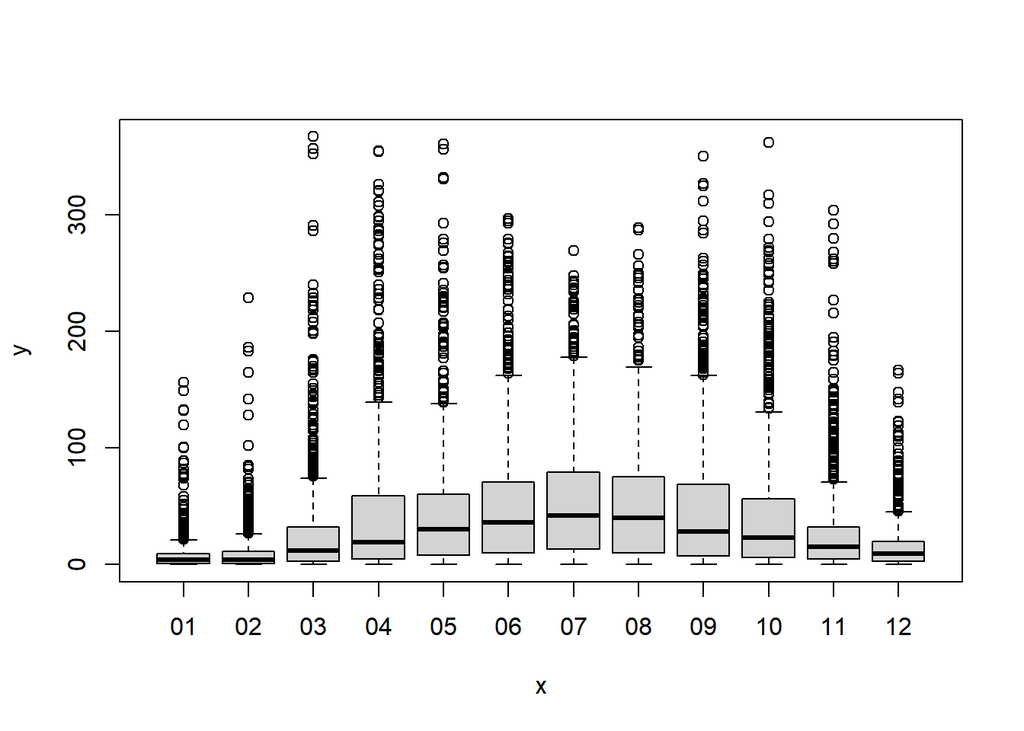

```r
plot(data$Month,data$casual)
```

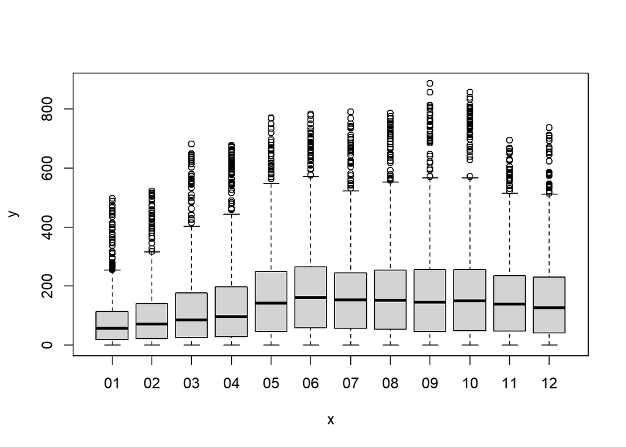

```r
plot(data$Month,data$registered)
```

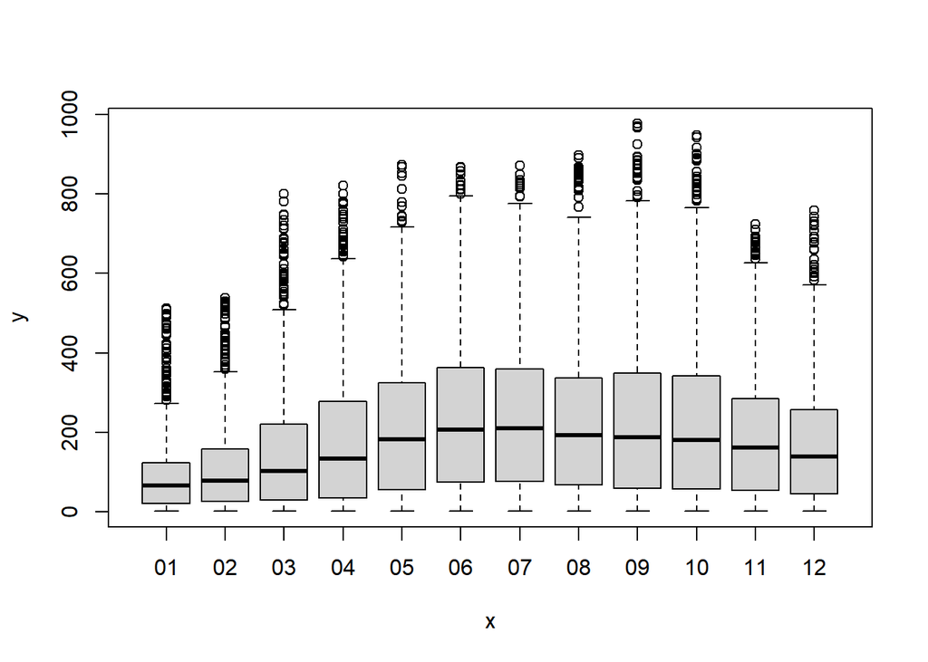

```r
plot(data$Month,data$count)
```

* Overall, the number of shared bike rentals is lowest on January.

#### 4.1.2.6 Let’s look at “Time” and “casual”,“registered”,“count”, respectively.

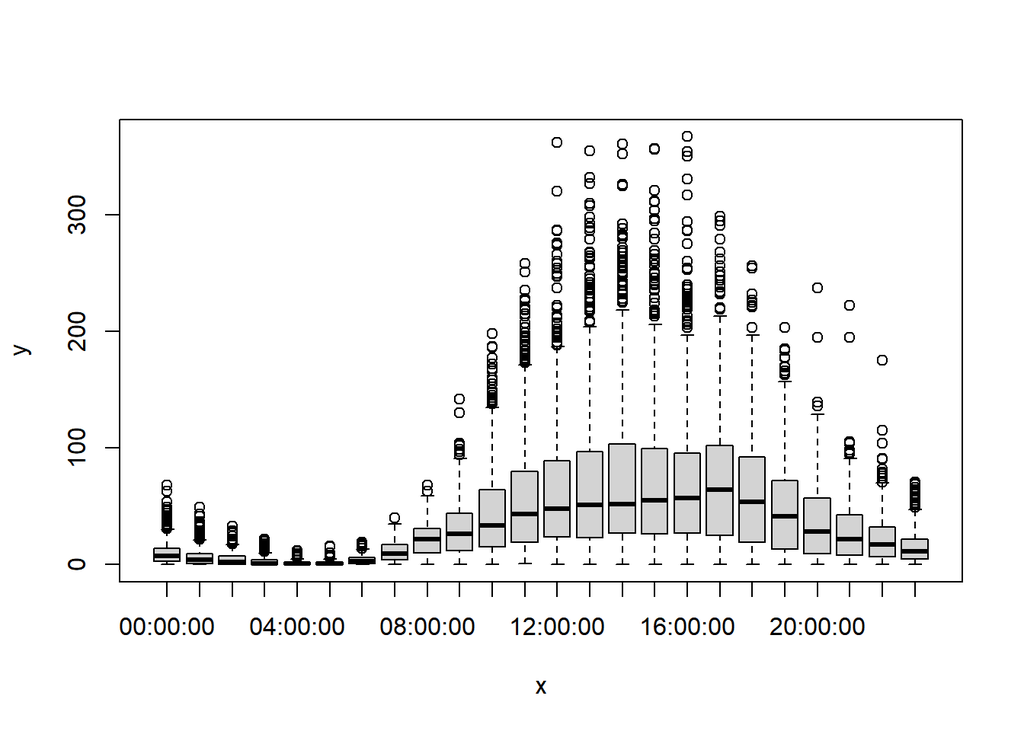

```r
plot(data$Time,data$casual)
```

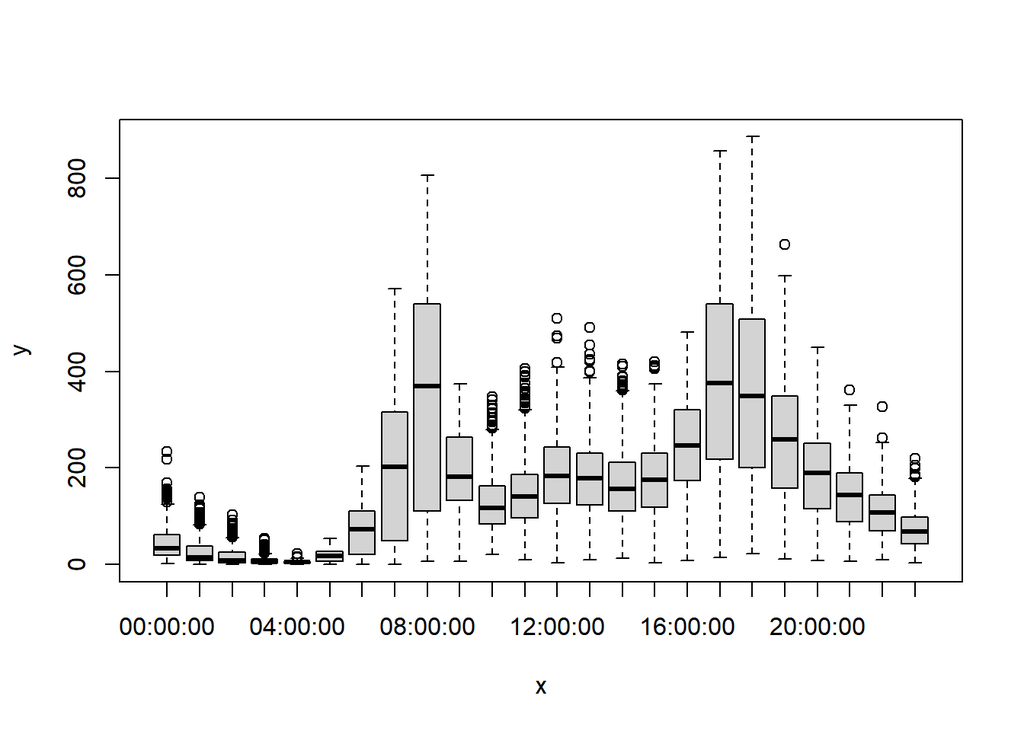

```r
plot(data$Time,data$registered)
```

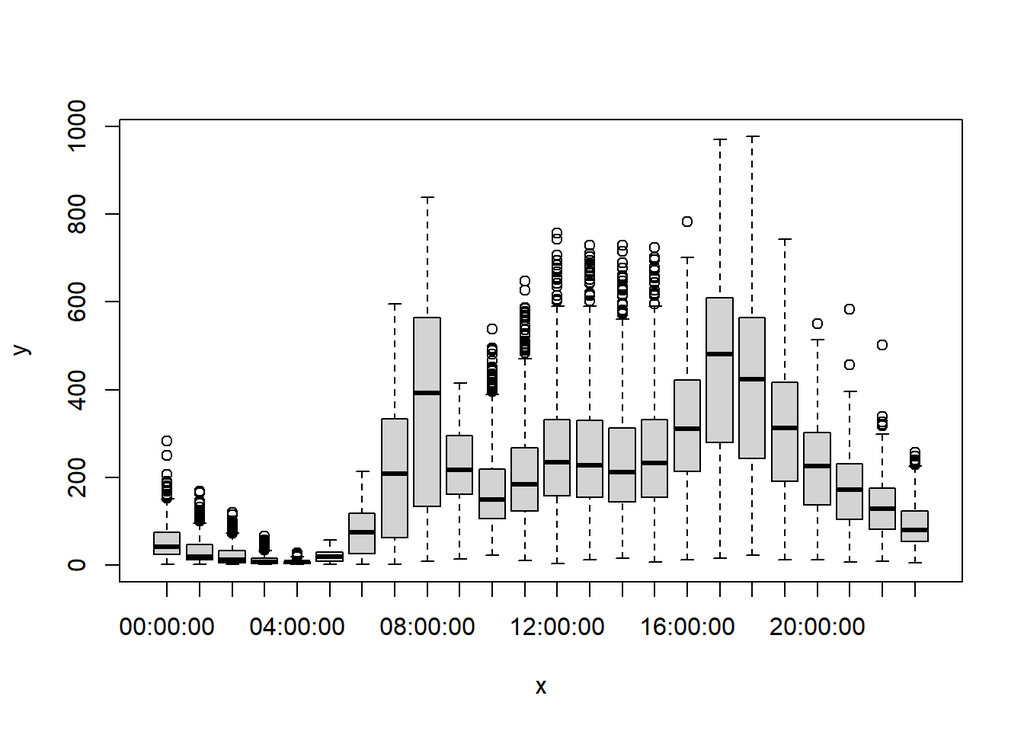

```r
plot(data$Time,data$count)
```

- Most of customers use shared bike between 06:00:00 and 20:00:00. Most of non-registered users use shared bike between 08:00:00 and 23:00:00, while most of the registered users use shared from 07:00:00 to 08:00:00 and 17:00:00 to 19:00:00.

### 4.1.3 Principal Components Analysis (PCA)

I would like to look at PCA for the variation of all of the numerical variables in the data in order to further decide which variables to keep.

```r
pcs.all<-prcomp(data[,c(5:9)], scale=T)
summary(pcs.all)
```

```
## Importance of components:
##                          PC1    PC2    PC3     PC4       PC5
## Standard deviation     1.696 0.9662 0.8776 0.64920 4.205e-15
## Proportion of Variance 0.575 0.1867 0.1540 0.08429 0.000e+00
## Cumulative Proportion  0.575 0.7617 0.9157 1.00000 1.000e+00
```

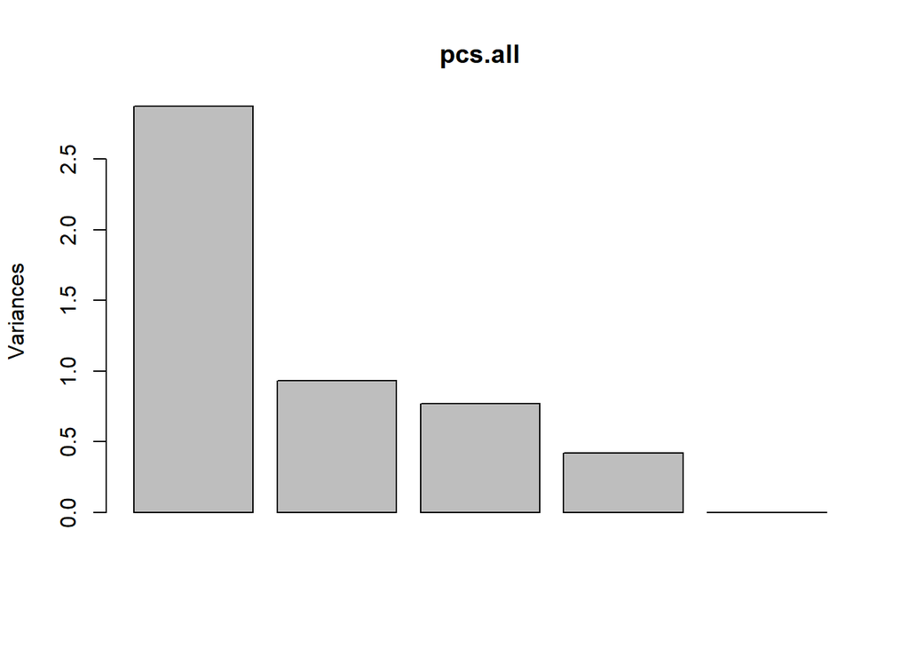

```r
plot(pcs.all)
```

```r
pcs.all$rotation[,1:3]
```

```
##                   PC1          PC2        PC3
## temp        0.3350046  0.621640175 -0.5496090
## humidity   -0.2768741  0.781573941  0.4720327
## casual      0.4793823  0.046858153 -0.3015530
## registered  0.5152883 -0.021936568  0.5144238
## count       0.5619460 -0.005363576  0.3457587
```

- The variations of the variables are not bad. There is no dimension reduced.
- After the data cleaning and dimension reduction, there are 10864 observations and 11 variables in the data set.The predictor variables are: “season”, “holiday”, “workingday”, “weather”, “temp”, “humidity”, “Month”, “Time”. The response variables are “casual”,“registered”,“count”.

```r
introduce(data)
```

| rows | columns | discrete_columns | continuous_columns | all_missing_columns | total_missing_values | complete_rows | total_observations | memory_usage |
| --- | --- | --- | --- | --- | --- | --- | --- | --- |
| 10864 | 11 | 6 | 5 | 0 | 0 | 10864 | 119504 | 704000 |

```r
names(data)
```

```
##  [1] "season"     "holiday"    "workingday" "weather"    "temp"
##  [6] "humidity"   "casual"     "registered" "count"      "Month"
## [11] "Time"
```

## 4.2 Partitioning and Over-Sampling

In order to prevent overfitting, I partition the data with 70% in the training sample and 30% in the validation sample.I set the seed as 13.

```r
set.seed(13)
```

```r
trainIndex = sample(1:nrow(data), size = round(0.7*nrow(data)), replace=FALSE)
head(trainIndex, 10)
```

```
##  [1]  9152  5989   717  4870   944  8086  2692 10560  8413  9212
```

```r
data.train<-data[trainIndex, ]
data.valid<-data[-trainIndex, ]
```

```r
na.omit(data.train)
```

[output not shown]

[output cut: 7595 more lines]

check the dimension of the training data set and validation data set

```r
dim(data.train)
```

[output not shown]

```r
dim(data.valid)
```

[output not shown]

```r
reg<-lm(count~season+holiday+workingday+weather+temp+humidity,data=data.train)
summary(reg)
```

```
##
## Call:
## lm(formula = count ~ season + holiday + workingday + weather +
##     temp + humidity, data = data.train)
##
## Residuals:
##     Min      1Q  Median      3Q     Max
## -371.27 -102.22  -31.34   63.30  685.64
##
## Coefficients:
##             Estimate Std. Error t value Pr(>|t|)
## (Intercept) 149.9176    13.0861  11.456  < 2e-16 ***
## season2      -4.8478     6.4887  -0.747    0.455
## season3     -39.6252     8.2500  -4.803 1.59e-06 ***
## season4      61.0782     5.4586  11.189  < 2e-16 ***
## holiday1      3.8034    11.0812   0.343    0.731
## workingday1   2.1712     3.9620   0.548    0.584
## weather1     -9.6859     7.3480  -1.318    0.187
## weather2      2.2340     7.4698   0.299    0.765
## temp         11.1483     0.3844  29.003  < 2e-16 ***
## humidity     -2.9659     0.1089 -27.237  < 2e-16 ***
## ---
## Signif. codes:  0 '***' 0.001 '**' 0.01 '*' 0.05 '.' 0.1 ' ' 1
##
## Residual standard error: 155.6 on 7595 degrees of freedom
## Multiple R-squared:  0.2756, Adjusted R-squared:  0.2747
## F-statistic:   321 on 9 and 7595 DF,  p-value: < 2.2e-16
```

- we can see that: As temperature increases by 1 Celsius degree, the number of total shared bike rentals increase by 11 units, all other factors remain equal.As humidity increase by 1 unit, the number of total shared bike rentals decrease by around 3 units, assuming everything else is constant. If it is a workday, the number of total shared bike rentals would be about 2 units more than that of a non workday, assuming everything else is constant. If it is a holiday, the number of total shared bike rental would be around 4 units more than that of a non holiday. If it is winter, the number of total shared bike rentals is estimated to be around 61 units more than other seasons, assuming everthing else is constant. This regression model explains 27.47% of the sample variation in the number of total shared bike rentals. I will perform stepwise model to see whether there is a better fit model.

Full regression for “casual” and “registered” below.

```r
reg2<-lm(casual~season+holiday+workingday+weather+temp+humidity, data=data.train)
summary(reg2)
```

```
##
## Call:
## lm(formula = casual ~ season + holiday + workingday + weather +
##     temp + humidity, data = data.train)
##
## Residuals:
##     Min      1Q  Median      3Q     Max
## -96.935 -21.801  -3.087  14.502 275.861
##
## Coefficients:
##              Estimate Std. Error t value Pr(>|t|)
## (Intercept)  52.91517    3.10029  17.068  < 2e-16 ***
## season2       1.12768    1.53726   0.734   0.4632
## season3     -11.90561    1.95453  -6.091 1.17e-09 ***
## season4       6.55377    1.29322   5.068 4.12e-07 ***
## holiday1     -6.57857    2.62530  -2.506   0.0122 *
## workingday1 -36.10436    0.93864 -38.464  < 2e-16 ***
## weather1     -7.51975    1.74085  -4.320 1.58e-05 ***
## weather2     -3.70835    1.76970  -2.095   0.0362 *
## temp          3.41942    0.09107  37.548  < 2e-16 ***
## humidity     -0.87964    0.02580 -34.097  < 2e-16 ***
## ---
## Signif. codes:  0 '***' 0.001 '**' 0.01 '*' 0.05 '.' 0.1 ' ' 1
##
## Residual standard error: 36.86 on 7595 degrees of freedom
## Multiple R-squared:  0.449,  Adjusted R-squared:  0.4483
## F-statistic: 687.6 on 9 and 7595 DF,  p-value: < 2.2e-16
```

- we can see that: As temperature increases by 1 Celsius degree, the number of non-registered user rentals increase by around 3 units, all other factors remain equal.As humidity increase by 1 unit, the number of non-registered user rentals decrease by around 1 unit, assuming everything else is constant. If it is a workday, the number of non-registered user rentals would be about 36 units less than that of a non workday, assuming everything else is constant. If it is a holiday, the number of non-registered user rental would be around 7 units less than that of a non holiday.

```r
reg3<-lm(registered~season+holiday+workingday+weather+temp+humidity,data=data.train)
summary(reg3)
```

```
##
## Call:
## lm(formula = registered ~ season + holiday + workingday + weather +
##     temp + humidity, data = data.train)
##
## Residuals:
##     Min      1Q  Median      3Q     Max
## -274.33  -87.09  -27.71   48.46  640.67
##
## Coefficients:
##              Estimate Std. Error t value Pr(>|t|)
## (Intercept)  97.00246   11.42564   8.490  < 2e-16 ***
## season2      -5.97552    5.66532  -1.055  0.29157
## season3     -27.71955    7.20313  -3.848  0.00012 ***
## season4      54.52439    4.76598  11.440  < 2e-16 ***
## holiday1     10.38193    9.67513   1.073  0.28328
## workingday1  38.27559    3.45922  11.065  < 2e-16 ***
## weather1     -2.16615    6.41562  -0.338  0.73565
## weather2      5.94239    6.52195   0.911  0.36225
## temp          7.72891    0.33562  23.029  < 2e-16 ***
## humidity     -2.08628    0.09508 -21.943  < 2e-16 ***
## ---
## Signif. codes:  0 '***' 0.001 '**' 0.01 '*' 0.05 '.' 0.1 ' ' 1
##
## Residual standard error: 135.8 on 7595 degrees of freedom
## Multiple R-squared:  0.2103, Adjusted R-squared:  0.2094
## F-statistic: 224.8 on 9 and 7595 DF,  p-value: < 2.2e-16
```

- we can see that: As temperature increases by 1 Celsius degree, the number of registered user rentals increase by around 8 units, all other factors remain equal.As humidity increase by 1 unit, the number of registered user rentals decrease by around 2 unit, assuming everything else is constant. If it is a workday, the number of registered user rentals would be about 38 units more than that of a non workday, assuming everything else is constant. If it is a holiday, the number of registered user rental would be around 10 units more than that of a non holiday.

### 4.2.1 Perform stepwise regression

```r
null<-lm(count~1, data=data.train)
lm.step<-step(null, scope=list(lower=null, upper=reg), direction="both", trace=0)
summary(lm.step)
```

```
##
## Call:
## lm(formula = count ~ temp + humidity + season + weather, data = data.train)
##
## Residuals:
##     Min      1Q  Median      3Q     Max
## -370.82 -102.15  -31.68   62.99  686.24
##
## Coefficients:
##             Estimate Std. Error t value Pr(>|t|)
## (Intercept) 151.5139    12.7752  11.860  < 2e-16 ***
## temp         11.1584     0.3839  29.070  < 2e-16 ***
## humidity     -2.9666     0.1089 -27.248  < 2e-16 ***
## season2      -4.9576     6.4853  -0.764    0.445
## season3     -39.7559     8.2422  -4.823 1.44e-06 ***
## season4      61.0667     5.4568  11.191  < 2e-16 ***
## weather1     -9.8171     7.3418  -1.337    0.181
## weather2      2.1554     7.4654   0.289    0.773
## ---
## Signif. codes:  0 '***' 0.001 '**' 0.01 '*' 0.05 '.' 0.1 ' ' 1
##
## Residual standard error: 155.6 on 7597 degrees of freedom
## Multiple R-squared:  0.2755, Adjusted R-squared:  0.2749
## F-statistic: 412.7 on 7 and 7597 DF,  p-value: < 2.2e-16
```

This regression model explains 27.49% of the sample variation in the number of total shared bike rentals. stepwise regression for “casual”,“registered”:

```r
null2<-lm(casual~1, data=data.train)
lm.step2<-step(null2, scope=list(lower=null2, upper=reg2), direction="both", trace=0)
summary(lm.step2)
```

```
##
## Call:
## lm(formula = casual ~ temp + workingday + humidity + season +
##     weather + holiday, data = data.train)
##
## Residuals:
##     Min      1Q  Median      3Q     Max
## -96.935 -21.801  -3.087  14.502 275.861
##
## Coefficients:
##              Estimate Std. Error t value Pr(>|t|)
## (Intercept)  52.91517    3.10029  17.068  < 2e-16 ***
## temp          3.41942    0.09107  37.548  < 2e-16 ***
## workingday1 -36.10436    0.93864 -38.464  < 2e-16 ***
## humidity     -0.87964    0.02580 -34.097  < 2e-16 ***
## season2       1.12768    1.53726   0.734   0.4632
## season3     -11.90561    1.95453  -6.091 1.17e-09 ***
## season4       6.55377    1.29322   5.068 4.12e-07 ***
## weather1     -7.51975    1.74085  -4.320 1.58e-05 ***
## weather2     -3.70835    1.76970  -2.095   0.0362 *
## holiday1     -6.57857    2.62530  -2.506   0.0122 *
## ---
## Signif. codes:  0 '***' 0.001 '**' 0.01 '*' 0.05 '.' 0.1 ' ' 1
##
## Residual standard error: 36.86 on 7595 degrees of freedom
## Multiple R-squared:  0.449,  Adjusted R-squared:  0.4483
## F-statistic: 687.6 on 9 and 7595 DF,  p-value: < 2.2e-16
```

```r
null3<-lm(registered~1, data=data.train)
lm.step3<-step(null3, scope=list(lower=null3, upper=reg3), direction="both", trace=0)
summary(lm.step3)
```

```
##
## Call:
## lm(formula = registered ~ temp + humidity + season + workingday +
##     weather, data = data.train)
##
## Residuals:
##     Min      1Q  Median      3Q     Max
## -274.25  -86.85  -27.89   48.28  640.63
##
## Coefficients:
##              Estimate Std. Error t value Pr(>|t|)
## (Intercept)  97.88063   11.39641   8.589  < 2e-16 ***
## temp          7.73117    0.33561  23.036  < 2e-16 ***
## humidity     -2.08673    0.09508 -21.948  < 2e-16 ***
## season2      -6.08850    5.66440  -1.075 0.282467
## season3     -27.64868    7.20289  -3.839 0.000125 ***
## season4      54.60239    4.76547  11.458  < 2e-16 ***
## workingday1  37.34807    3.34952  11.150  < 2e-16 ***
## weather1     -2.15848    6.41568  -0.336 0.736550
## weather2      6.01248    6.52169   0.922 0.356599
## ---
## Signif. codes:  0 '***' 0.001 '**' 0.01 '*' 0.05 '.' 0.1 ' ' 1
##
## Residual standard error: 135.8 on 7596 degrees of freedom
## Multiple R-squared:  0.2102, Adjusted R-squared:  0.2094
## F-statistic: 252.7 on 8 and 7596 DF,  p-value: < 2.2e-16
```

- I would like to compare prediction accuracy in order to choose which model to use. I Calculate RMSE on the validation data.

```r
p.reg <- predict(reg,newdata = data.valid)
p.step<-predict(lm.step, newdata=data.valid)
head(p.reg)
```

```
##         1         2         3         4         5         6
##  9.691831 27.487353  3.516114 88.512894 80.891031 80.891031
```

```r
head(p.step)
```

```
##         1         2         3         4         5         6
## 11.200740 29.000362  5.017438 90.083101 82.600761 82.600761
```

I would like to get the RMSE to see which model gives best precision on the validation data.

```r
accuracy(p.reg, data.valid$count)
```

```
##                ME     RMSE      MAE       MPE     MAPE
## Test set 1.110319 149.8903 112.7061 -424.6912 465.8818
```

```r
accuracy(p.step, data.valid$count)
```

```
##                ME     RMSE      MAE       MPE     MAPE
## Test set 1.105658 149.8349 112.6139 -424.0003 465.1743
```

```r
p.reg2 <- predict(reg2,newdata = data.valid)
p.step2<-predict(lm.step2, newdata=data.valid)
head(p.reg2)
```

```
##         1         2         3         4         5         6
##  7.791763 13.069600  5.867474 31.817459 34.389395 34.389395
```

```r
accuracy(p.reg2, data.valid$casual)
```

```
##                 ME     RMSE      MAE MPE MAPE
## Test set 0.9011562 37.36909 24.77975 NaN  Inf
```

```r
accuracy(p.step2, data.valid$casual)
```

```
##                 ME     RMSE      MAE MPE MAPE
## Test set 0.9011562 37.36909 24.77975 NaN  Inf
```

```r
p.reg3 <- predict(reg3,newdata = data.valid)
p.step3<-predict(lm.step3, newdata=data.valid)
head(p.reg3)
```

```
##         1         2         3         4         5         6
##  1.900068 14.417753 -2.351360 56.695435 46.501635 46.501635
```

```r
head(p.step3)
```

```
##         1         2         3         4         5         6
##  2.771686 15.292071 -1.481144 57.582268 47.379099 47.379099
```

```r
accuracy(p.reg3, data.valid$registered)
```

```
##                 ME     RMSE     MAE MPE MAPE
## Test set 0.2091628 130.3721 95.7386 NaN  Inf
```

```r
accuracy(p.step3,data.valid$registered)
```

```
##                 ME     RMSE      MAE MPE MAPE
## Test set 0.2083659 130.3313 95.66771 NaN  Inf
```

# 5 Conclusion

During 07:00:00 to 20:00:00 customers demand most of the shared rental bikes.The peaks are 08:00:00:00 and 17:00:00 to 18:00:00

To improve the customer service, Capital Bike Share should prepare more bikes when the weather is Clear, Few clouds, Partly cloudy, Partly cloudy and when the time is 08:00:00:00 or between 17:00:00 and 18:00:00.